# リアルタイム勝率計算アルゴリズム

flaty

2019/1/4

# 概要

スポーツのリアルタイム勝率算出のアルゴリズムを作成する  
点差と残り時間から勝率を算出するものとする。

今回は例としてサッカーとラグビーについてモデルを考えてみた

# 準備

libraryの読み込みとか

```r
library(tidyverse)
library(rvest)
#library(scales)
```

```r
## Options
#ggplotの文字化け対策
theme_set( theme_bw(base_family = "HiraKakuProN-W3"))
```

# 結果

## サッカー(同レベルver)

### ベルヌーイモデル

サッカー例に説明する  
2018年のJ1の結果を調べたところ1試合あたり1.33得点だった(もちろん失点も同じ)  
サッカーの試合時間は90分であるので、1分あたりの得点期待値は1.33/90点である  
得点期待値が試合を通して一定であると仮定すると、残り時間t分の場合の各得点の確率はベルヌーイ試行を用いて求めることができる  
例えば、試合開始時=残り時間90分における各得点数の確率は次のように求められる(10点以上の確率はほぼ0なのでグラフからは除外)

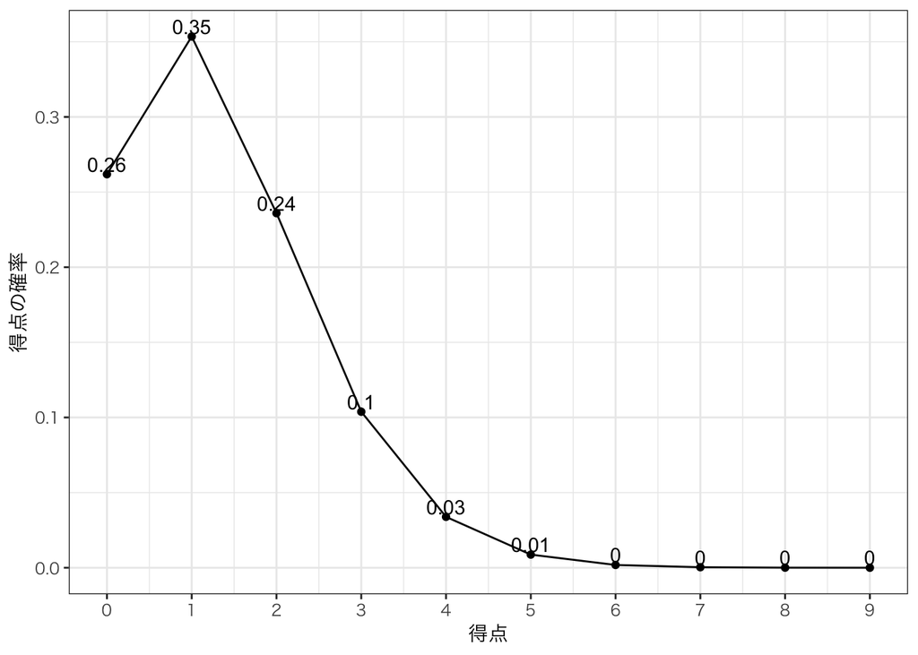

```r
t <- 90
p <- 1.33 / 90
res <- matrix(0, nrow=10, ncol=2)

for (n in 0:10-1) {
  res[n+1, 1] <- n
  res[n+1, 2] <- choose(t, n) * (p^n) * ((1-p)^(t-n))
}

res %>%
  as.data.frame() %>%
  ggplot(aes(x=V1, y=V2)) +
  geom_line() +
  geom_point() +
  geom_text(aes(label=round(V2, 2), vjust=-0.2)) +
  scale_x_continuous(breaks=seq(0, 9, by=1)) +
  xlab("得点") +
  ylab("得点の確率")
```

ここで残り時間45分(後半開始時)に1点リードしているチームの勝率を考える  
残り時間45分の場合の各得点の確率は次のようになる

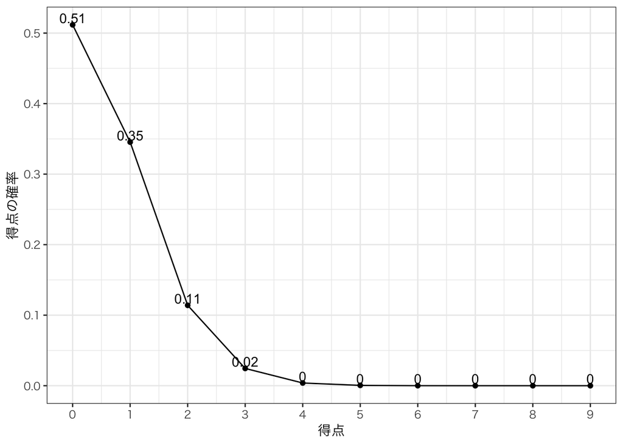

```r
t <- 45
p <- 1.33 / 90
res <- matrix(0, nrow=10, ncol=2)

for (n in 0:10-1) {
  res[n+1, 1] <- n
  res[n+1, 2] <- choose(t, n) * (p^n) * ((1-p)^(t-n))
}

res %>%
  as.data.frame() %>%
  ggplot(aes(x=V1, y=V2)) +
  geom_line() +
  geom_point() +
  geom_text(aes(label=round(V2, 2), vjust=-0.2)) +
  scale_x_continuous(breaks=seq(0, 9, by=1)) +
  xlab("得点") +
  ylab("得点の確率")
```

つまり、リードしている側は  
相手に得点されない: 約51%  
1失点だが1得点以上: 0.350.49=0.17 約17%  
2失点だが2得点以上: 0.110.14=0..15 約1.5%  
3失点だが3得点以上: ほぼ0%  
のように約7割弱の確率で勝利できる  
(引き分けを入れればより確率が高くなる)

### シミュレーションモデル

毎回このような場合分けを考えるのは面倒なのでシミュレーションを行い勝率を求める

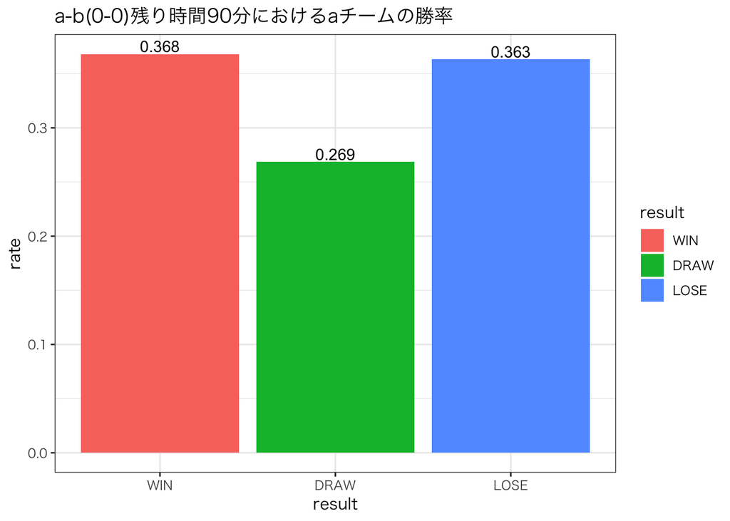

```r
t <- 90 #残り時間
p <- 1.33 / 90 #得点期待値
i <- 10000 #試行回数
a <- 0 #現在のAチームの得点
b <- 0 #現在のBチームの得点

res <- matrix(0, nrow=i, ncol=1)

for (n in 1:i) {

  res_a <- runif(t)
  res_b <- runif(t)

  score_a <- a + sum(res_a < p)
  score_b <- b + sum(res_b < p)

  if (score_a == score_b) { #引き分け
   res[n, 1] <- "DRAW"
 } else if (score_a > score_b) { #aの勝ち
   res[n, 1] <- "WIN"
 } else  #aの負け
   res[n, 1] <- "LOSE"

}

tmp <- paste0("a-b(", a, "-", b, ")残り時間", t, "分におけるaチームの勝率")

res %>%
  as.data.frame() %>%
  dplyr::rename(result=V1) %>%
  dplyr::group_by(result) %>%
  dplyr::summarise(rate = n() / i) %>%
  transform(result = factor(result, levels = c("WIN", "DRAW", "LOSE"))) %>%
  ggplot(aes(x=result, y=rate, fill=result), position = position_stack(reverse = TRUE)) +
  geom_col() +
  geom_text(aes(label=round(rate, 3), vjust=-0.2)) +
  ggtitle(tmp)
```

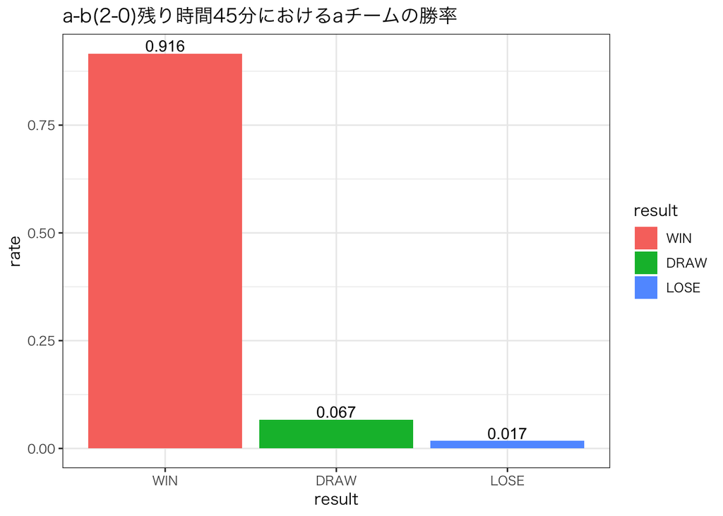

```r
t <- 45 #残り時間
p <- 1.33 / 90 #得点期待値
i <- 10000 #試行回数
a <- 2 #現在のAチームの得点
b <- 0 #現在のBチームの得点

res <- matrix(0, nrow=i, ncol=1)

for (n in 1:i) {

  res_a <- runif(t)
  res_b <- runif(t)

  score_a <- a + sum(res_a < p)
  score_b <- b + sum(res_b < p)

  if (score_a == score_b) { #引き分け
   res[n, 1] <- "DRAW"
 } else if (score_a > score_b) { #aの勝ち
   res[n, 1] <- "WIN"
 } else  #aの負け
   res[n, 1] <- "LOSE"

}

tmp <- paste0("a-b(", a, "-", b, ")残り時間", t, "分におけるaチームの勝率")

res %>%
  as.data.frame() %>%
  dplyr::rename(result=V1) %>%
  dplyr::group_by(result) %>%
  dplyr::summarise(rate = n() / i) %>%
  transform(result = factor(result, levels = c("WIN", "DRAW", "LOSE"))) %>%
  ggplot(aes(x=result, y=rate, fill=result)) +
  geom_col() +
  geom_text(aes(label=round(rate, 3), vjust=-0.2)) +
  ggtitle(tmp)
```

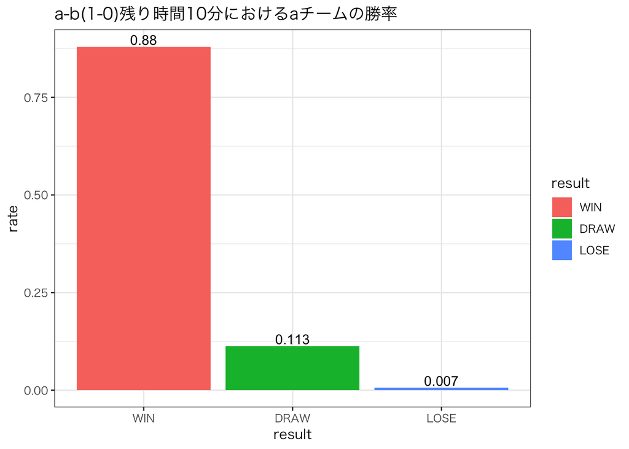

```r
t <- 10 #残り時間
p <- 1.33 / 90 #得点期待値
i <- 10000 #試行回数
a <- 1 #現在のAチームの得点
b <- 0 #現在のBチームの得点

res <- matrix(0, nrow=i, ncol=1)

for (n in 1:i) {

  res_a <- runif(t)
  res_b <- runif(t)

  score_a <- a + sum(res_a < p)
  score_b <- b + sum(res_b < p)

  if (score_a == score_b) { #引き分け
   res[n, 1] <- "DRAW"
 } else if (score_a > score_b) { #aの勝ち
   res[n, 1] <- "WIN"
 } else  #aの負け
   res[n, 1] <- "LOSE"

}

tmp <- paste0("a-b(", a, "-", b, ")残り時間", t, "分におけるaチームの勝率")

res %>%
  as.data.frame() %>%
  dplyr::rename(result=V1) %>%
  dplyr::group_by(result) %>%
  dplyr::summarise(rate = n() / i) %>%
  transform(result = factor(result, levels = c("WIN", "DRAW", "LOSE"))) %>%
  ggplot(aes(x=result, y=rate, fill=result)) +
  geom_col() +
  geom_text(aes(label=round(rate, 3), vjust=-0.2)) +
  ggtitle(tmp)
```

点差が一定の場合、残り時間が減るにつれてどのように勝率が変わるのかを調べてみる

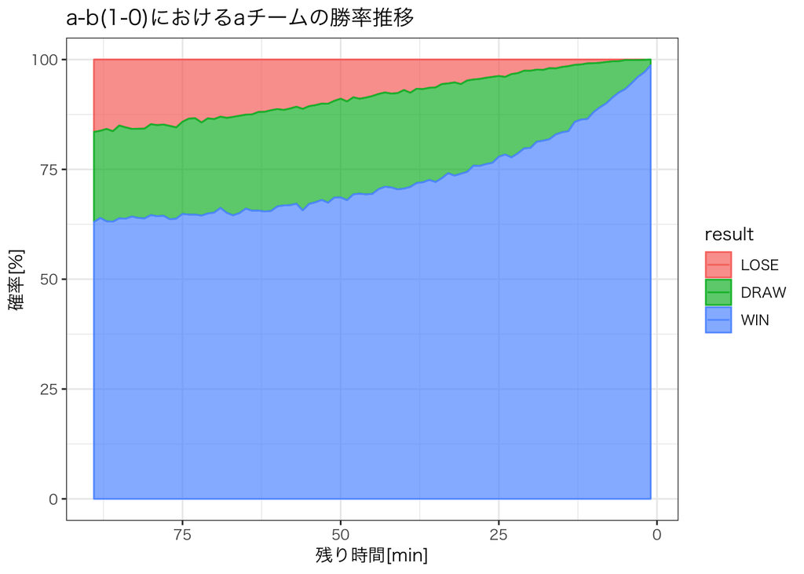

```r
time <- 89 #残り時間
p <- 1.33 / 90 #得点期待値
i <- 10000 #試行回数
a <- 1 #現在のAチームの得点
b <- 0 #現在のBチームの得点

res <- matrix(0, nrow=i, ncol=1)

df <- data.frame(matrix(rep(NA, 4), nrow=1))[numeric(0), ]
colnames(df) <- c("DRAW", "LOSE", "WIN", "remaining_time")

for (t in time:1) {

for (n in 1:i) {

  res_a <- runif(t)
  res_b <- runif(t)

  score_a <- a + sum(res_a < p)
  score_b <- b + sum(res_b < p)

  if (score_a == score_b) { #引き分け
   res[n, 1] <- "DRAW"
 } else if (score_a > score_b) { #aの勝ち
   res[n, 1] <- "WIN"
 } else  #aの負け
   res[n, 1] <- "LOSE"

}
  tmp <-
    res %>%
    as.data.frame() %>%
    dplyr::rename(result=V1) %>%
    dplyr::group_by(result) %>%
    dplyr::summarise(rate = n() / i * 100) %>%
    tidyr::spread(key = result, value = rate) %>%
    dplyr::mutate(remaining_time=t)

  df <- dplyr::bind_rows(df, tmp)

  res <- matrix(0, nrow=i, ncol=1)
}

tmp <- paste0("a-b(", a, "-", b, ")におけるaチームの勝率推移")

df %>%
  tidyr::gather(key = result, value = rate, WIN, DRAW, LOSE) %>%
  transform(result = factor(result, levels = c("LOSE", "DRAW", "WIN"))) %>%
  ggplot(aes(x = remaining_time, y = rate, color = result)) +
  geom_line(position="stack") +
  geom_ribbon(aes(ymin = 0, ymax = 1, group = result, fill = result), position = "stack", alpha = 0.7) +
  scale_x_reverse() +
  xlab("残り時間[min]") +
  ylab("確率[%]") +
  ggtitle(tmp)
```

## サッカー(レベル違うver)

### シミュレーションモデル

各チームの得点期待値が異なる場合を考える  
まずはJ1の結果をスクレイピングで取得する

```r
URL <- paste0("https://soccer.yahoo.co.jp/jleague/standings/j1")
URL %>%
  read_html() %>%
  html_node(xpath = '//*[@id="modSoccerStanding"]/div/div/table') %>%
  html_table() -> J1_2018
```

```r
J1_2018
```

```
##    順位               チーム名 勝点 試合数 勝数 引分数 敗数 得点 失点
## 1     1       川崎フロンターレ   69     34   21      6    7   57   27
## 2     2     サンフレッチェ広島   57     34   17      6   11   47   35
## 3     3       鹿島アントラーズ   56     34   16      8   10   50   39
## 4     4 北海道コンサドーレ札幌   55     34   15     10    9   48   48
## 5     5             浦和レッズ   51     34   14      9   11   51   39
## 6     6                 FC東京   50     34   14      8   12   39   34
## 7     7           セレッソ大阪   50     34   13     11   10   39   38
## 8     8         清水エスパルス   49     34   14      7   13   56   48
## 9     9             ガンバ大阪   48     34   14      6   14   41   46
## 10   10         ヴィッセル神戸   45     34   12      9   13   45   52
## 11   11           ベガルタ仙台   45     34   13      6   15   44   54
## 12   12        横浜F・マリノス   41     34   12      5   17   56   56
## 13   13         湘南ベルマーレ   41     34   10     11   13   38   43
## 14   14             サガン鳥栖   41     34   10     11   13   29   34
```

[output cut: 23 more lines]

首位の川崎フロンターレと最下位のV・ファーレン長崎で考えてみる  
川崎フロンターレは1試合あたり1.676得点/0.794失点  
V・ファーレン長崎は1試合あたり1.147得点/1.735失点

平均をとって  
川崎フロンターレの得点期待値は1.7055点  
のV・ファーレン長崎の得点期待値は0.9705点

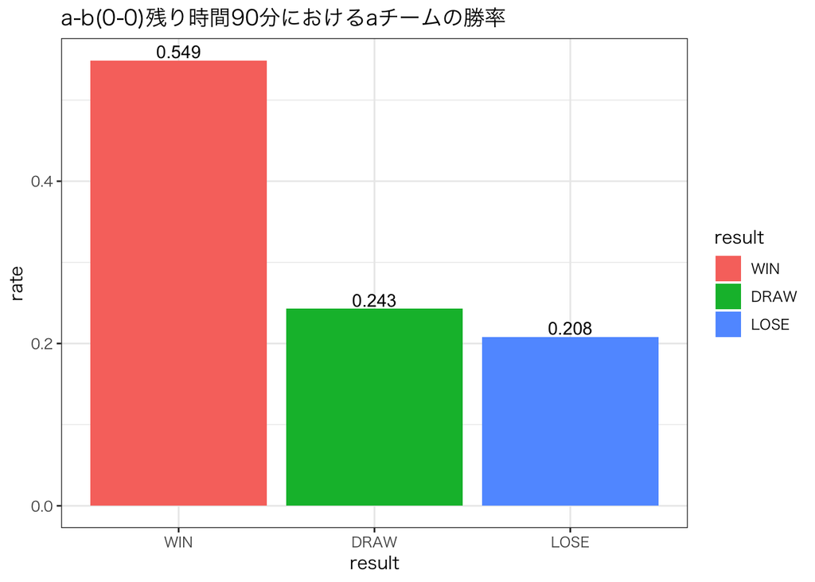

```r
t <- 90 #残り時間
pa <- 1.7055 / 90 #aチームの得点期待値
pb <- 0.9705 / 90 #bチームの得点期待値
i <- 10000 #試行回数
a <- 0 #現在のAチームの得点
b <- 0 #現在のBチームの得点

res <- matrix(0, nrow=i, ncol=1)

for (n in 1:i) {

  res_a <- runif(t)
  res_b <- runif(t)

  score_a <- a + sum(res_a < pa)
  score_b <- b + sum(res_b < pb)

  if (score_a == score_b) { #引き分け
   res[n, 1] <- "DRAW"
 } else if (score_a > score_b) { #aの勝ち
   res[n, 1] <- "WIN"
 } else  #aの負け
   res[n, 1] <- "LOSE"

}

tmp <- paste0("a-b(", a, "-", b, ")残り時間", t, "分におけるaチームの勝率")

res %>%
  as.data.frame() %>%
  dplyr::rename(result=V1) %>%
  dplyr::group_by(result) %>%
  dplyr::summarise(rate = n() / i) %>%
  transform(result = factor(result, levels = c("WIN", "DRAW", "LOSE"))) %>%
  ggplot(aes(x=result, y=rate, fill=result)) +
  geom_col() +
  geom_text(aes(label=round(rate, 3), vjust=-0.2)) +
  ggtitle(tmp)
```

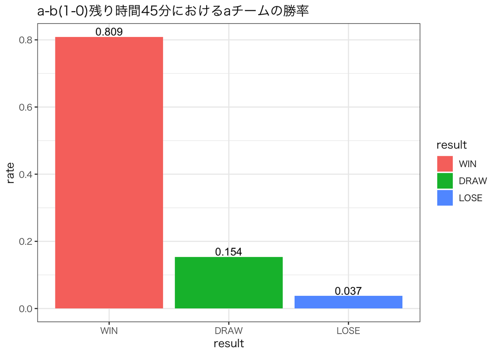

```r
t <- 45 #残り時間
pa <- 1.7055 / 90 #aチームの得点期待値
pb <- 0.9705 / 90 #bチームの得点期待値
i <- 10000 #試行回数
a <- 1 #現在のAチームの得点
b <- 0 #現在のBチームの得点

res <- matrix(0, nrow=i, ncol=1)

for (n in 1:i) {

  res_a <- runif(t)
  res_b <- runif(t)

  score_a <- a + sum(res_a < pa)
  score_b <- b + sum(res_b < pb)

  if (score_a == score_b) { #引き分け
   res[n, 1] <- "DRAW"
 } else if (score_a > score_b) { #aの勝ち
   res[n, 1] <- "WIN"
 } else  #aの負け
   res[n, 1] <- "LOSE"

}

tmp <- paste0("a-b(", a, "-", b, ")残り時間", t, "分におけるaチームの勝率")

res %>%
  as.data.frame() %>%
  dplyr::rename(result=V1) %>%
  dplyr::group_by(result) %>%
  dplyr::summarise(rate = n() / i) %>%
  transform(result = factor(result, levels = c("WIN", "DRAW", "LOSE"))) %>%
  ggplot(aes(x=result, y=rate, fill=result)) +
  geom_col() +
  geom_text(aes(label=round(rate, 3), vjust=-0.2)) +
  ggtitle(tmp)
```

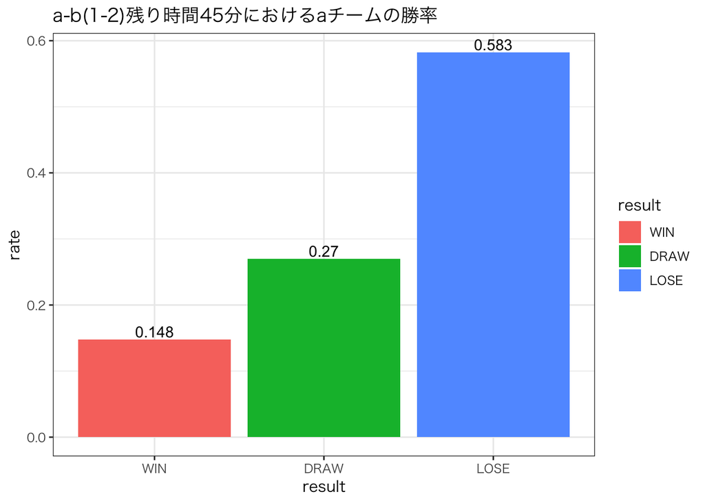

```r
t <- 45 #残り時間
pa <- 1.7055 / 90 #aチームの得点期待値
pb <- 0.9705 / 90 #bチームの得点期待値
i <- 10000 #試行回数
a <- 1 #現在のAチームの得点
b <- 2 #現在のBチームの得点

res <- matrix(0, nrow=i, ncol=1)

for (n in 1:i) {

  res_a <- runif(t)
  res_b <- runif(t)

  score_a <- a + sum(res_a < pa)
  score_b <- b + sum(res_b < pb)

  if (score_a == score_b) { #引き分け
   res[n, 1] <- "DRAW"
 } else if (score_a > score_b) { #aの勝ち
   res[n, 1] <- "WIN"
 } else  #aの負け
   res[n, 1] <- "LOSE"

}

tmp <- paste0("a-b(", a, "-", b, ")残り時間", t, "分におけるaチームの勝率")

res %>%
  as.data.frame() %>%
  dplyr::rename(result=V1) %>%
  dplyr::group_by(result) %>%
  dplyr::summarise(rate = n() / i) %>%
  transform(result = factor(result, levels = c("WIN", "DRAW", "LOSE"))) %>%
  ggplot(aes(x=result, y=rate, fill=result)) +
  geom_col() +
  geom_text(aes(label=round(rate, 3), vjust=-0.2)) +
  ggtitle(tmp)
```

点差が一定の場合、残り時間が減るにつれてどのように勝率が変わるのかを調べてみる

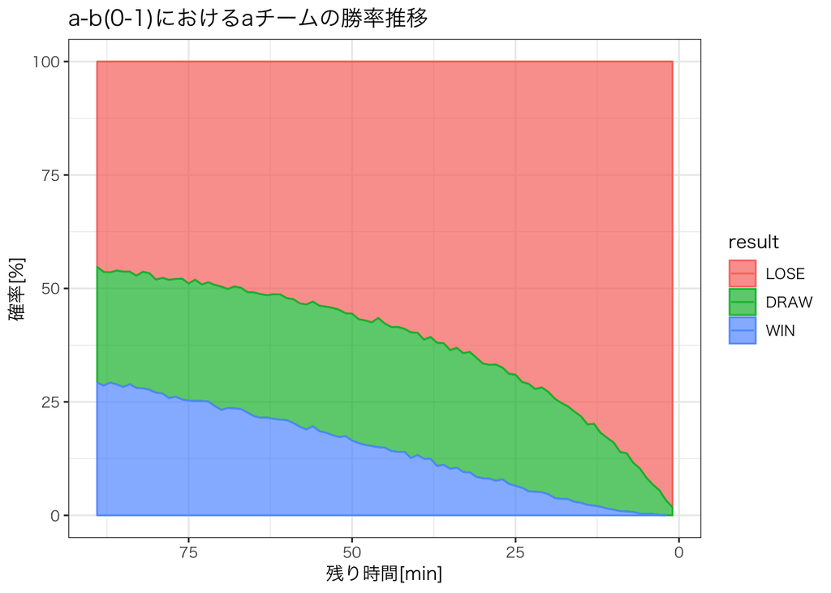

```r
time <- 89 #残り時間
pa <- 1.7055 / 90 #aチームの得点期待値
pb <- 0.9705 / 90 #bチームの得点期待値
i <- 10000 #試行回数
a <- 0 #現在のAチームの得点
b <- 1 #現在のBチームの得点

res <- matrix(0, nrow=i, ncol=1)

df <- data.frame(matrix(rep(NA, 4), nrow=1))[numeric(0), ]
colnames(df) <- c("DRAW", "LOSE", "WIN", "remaining_time")

for (t in time:1) {

for (n in 1:i) {

  res_a <- runif(t)
  res_b <- runif(t)

  score_a <- a + sum(res_a < pa)
  score_b <- b + sum(res_b < pb)

  if (score_a == score_b) { #引き分け
   res[n, 1] <- "DRAW"
 } else if (score_a > score_b) { #aの勝ち
   res[n, 1] <- "WIN"
 } else  #aの負け
   res[n, 1] <- "LOSE"

}
  tmp <-
    res %>%
    as.data.frame() %>%
    dplyr::rename(result=V1) %>%
    dplyr::group_by(result) %>%
    dplyr::summarise(rate = n() / i * 100) %>%
    tidyr::spread(key = result, value = rate) %>%
    dplyr::mutate(remaining_time=t)

  df <- dplyr::bind_rows(df, tmp)

  res <- matrix(0, nrow=i, ncol=1)
}

tmp <- paste0("a-b(", a, "-", b, ")におけるaチームの勝率推移")

df %>%
  tidyr::gather(key = result, value = rate, WIN, DRAW, LOSE) %>%
  transform(result = factor(result, levels = c("LOSE", "DRAW", "WIN"))) %>%
  ggplot(aes(x = remaining_time, y = rate, color = result)) +
  geom_line(position="stack") +
  geom_ribbon(aes(ymin = 0, ymax = 1, group = result, fill = result), position = "stack", alpha = 0.7) +
  scale_x_reverse() +
  xlab("残り時間[min]") +
  ylab("確率[%]") +
  ggtitle(tmp)
```

## ラグビー(同レベルver)

### シミュレーションモデル

ラグビーははじめからシミュレーションで行う

ラグビーはサッカーと違い、複数の得点パターンがある  
(T トライ(5点) G ゴール(2点) PG ペナルティゴール(3点) DG ドロップゴール(3点))  
つまり、  
7点: T＋G  
5点: T(Gは失敗)  
3点: PG or DG  
の3ケースが考えられる

それぞれどのくらい起こりうるか調べるためにラグビートップリーグ2017-2018シーズンの結果をスクレイピングする

```r
URL <- paste0("https://sportsnavi.ht.kyodo-d.jp/rugby/stats/topleague/standings/")
URL %>%
  read_html() %>%
  html_node(xpath = '//*[@id="main"]/section[2]/div/table') %>%
  html_table() -> red

Sys.sleep(1)

URL %>%
  read_html() %>%
  html_node(xpath = '//*[@id="main"]/section[3]/div/table') %>%
  html_table() -> white
```

リーグ戦は8チームでの総当たりなのを考慮して1試合あたりのトライ数等を求める

```r
dplyr::bind_rows(red, white) %>%
  dplyr::select(T, G, PG, DG) %>%
  dplyr::summarise(T = sum(T)/(7*16), G = sum(G)/(7*16), PG = sum(PG)/(7*16), DG = sum(DG)/(7*16))
```

```
##      T      G       PG         DG
## 1 3.75 2.4375 1.017857 0.01785714
```

つまり1試合あたり、  
7点: T＋Gは2.4375回  
5点: T(Gは失敗)は1.3125回 3点: PG or DGは 1.0357回  
ラグビーの試合は80分なので、上の数字を80で割ったものが1分あたりに起こりうる確率である

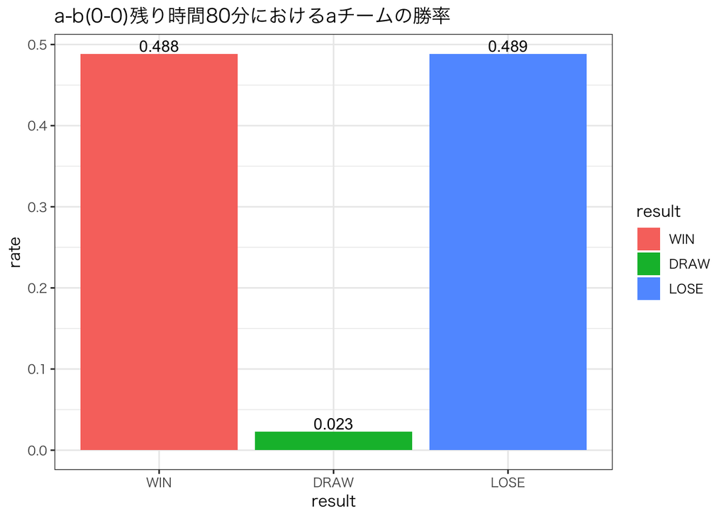

```r
t <- 80 #残り時間
p7 <- 2.4375 / 80 #得点期待値
p5 <- 1.3125 / 80 #得点期待値
p3 <- 1.0357 / 80 #得点期待値
i <- 10000 #試行回数
a <- 0 #現在のAチームの得点
b <- 0 #現在のBチームの得点

res <- matrix(0, nrow=i, ncol=1)

for (n in 1:i) {

  res_a <- runif(t)
  res_b <- runif(t)

  score_a <- a + 7 * sum(res_a < p7) + 5 * sum(res_a >= p7 & res_a < (p7+p5)) + 3 * sum(res_a >= (p7+p5) & res_a < (p7+p5+p3))
  score_b <- b + 7 * sum(res_b < p7) + 5 * sum(res_b >= p7 & res_b < (p7+p5)) + 3 * sum(res_b >= (p7+p5) & res_b < (p7+p5+p3))

  if (score_a == score_b) { #引き分け
   res[n, 1] <- "DRAW"
 } else if (score_a > score_b) { #aの勝ち
   res[n, 1] <- "WIN"
 } else  #aの負け
   res[n, 1] <- "LOSE"

}

tmp <- paste0("a-b(", a, "-", b, ")残り時間", t, "分におけるaチームの勝率")

res %>%
  as.data.frame() %>%
  dplyr::rename(result=V1) %>%
  dplyr::group_by(result) %>%
  dplyr::summarise(rate = n() / i) %>%
  transform(result = factor(result, levels = c("WIN", "DRAW", "LOSE"))) %>%
  ggplot(aes(x=result, y=rate, fill=result)) +
  geom_col() +
  geom_text(aes(label=round(rate, 3), vjust=-0.2)) +
  ggtitle(tmp)
```

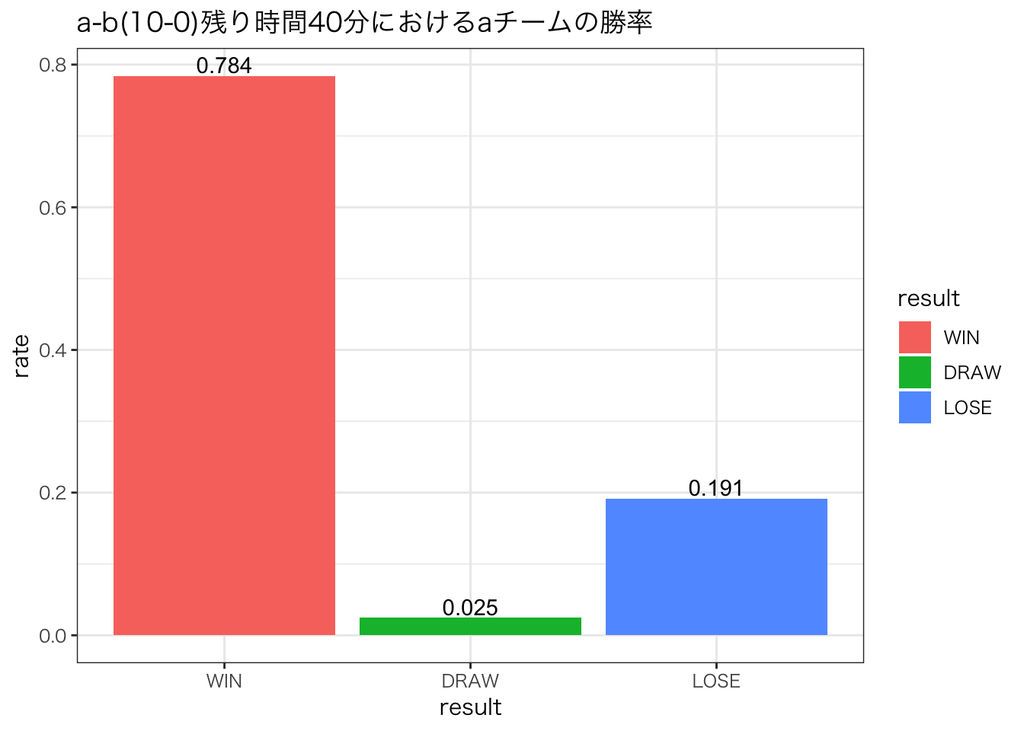

```r
t <- 40 #残り時間
p7 <- 2.4375 / 80 #得点期待値
p5 <- 1.3125 / 80 #得点期待値
p3 <- 1.0357 / 80 #得点期待値
i <- 10000 #試行回数
a <- 10 #現在のAチームの得点
b <- 0 #現在のBチームの得点

res <- matrix(0, nrow=i, ncol=1)

for (n in 1:i) {

  res_a <- runif(t)
  res_b <- runif(t)

  score_a <- a + 7 * sum(res_a < p7) + 5 * sum(res_a >= p7 & res_a < (p7+p5)) + 3 * sum(res_a >= (p7+p5) & res_a < (p7+p5+p3))
  score_b <- b + 7 * sum(res_b < p7) + 5 * sum(res_b >= p7 & res_b < (p7+p5)) + 3 * sum(res_b >= (p7+p5) & res_b < (p7+p5+p3))

  if (score_a == score_b) { #引き分け
   res[n, 1] <- "DRAW"
 } else if (score_a > score_b) { #aの勝ち
   res[n, 1] <- "WIN"
 } else  #aの負け
   res[n, 1] <- "LOSE"

}

tmp <- paste0("a-b(", a, "-", b, ")残り時間", t, "分におけるaチームの勝率")

res %>%
  as.data.frame() %>%
  dplyr::rename(result=V1) %>%
  dplyr::group_by(result) %>%
  dplyr::summarise(rate = n() / i) %>%
  transform(result = factor(result, levels = c("WIN", "DRAW", "LOSE"))) %>%
  ggplot(aes(x=result, y=rate, fill=result)) +
  geom_col() +
  geom_text(aes(label=round(rate, 3), vjust=-0.2)) +
  ggtitle(tmp)
```

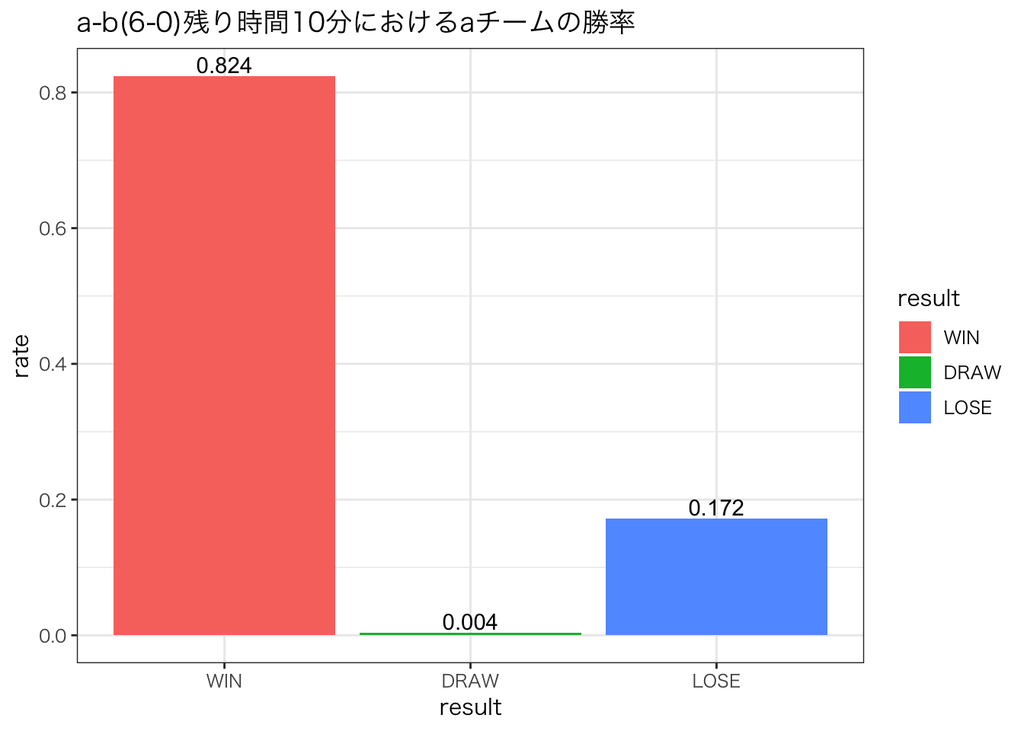

```r
t <- 10 #残り時間
p7 <- 2.4375 / 80 #得点期待値
p5 <- 1.3125 / 80 #得点期待値
p3 <- 1.0357 / 80 #得点期待値
i <- 10000 #試行回数
a <- 6 #現在のAチームの得点
b <- 0 #現在のBチームの得点

res <- matrix(0, nrow=i, ncol=1)

for (n in 1:i) {

  res_a <- runif(t)
  res_b <- runif(t)

  score_a <- a + 7 * sum(res_a < p7) + 5 * sum(res_a >= p7 & res_a < (p7+p5)) + 3 * sum(res_a >= (p7+p5) & res_a < (p7+p5+p3))
  score_b <- b + 7 * sum(res_b < p7) + 5 * sum(res_b >= p7 & res_b < (p7+p5)) + 3 * sum(res_b >= (p7+p5) & res_b < (p7+p5+p3))

  if (score_a == score_b) { #引き分け
   res[n, 1] <- "DRAW"
 } else if (score_a > score_b) { #aの勝ち
   res[n, 1] <- "WIN"
 } else  #aの負け
   res[n, 1] <- "LOSE"

}

tmp <- paste0("a-b(", a, "-", b, ")残り時間", t, "分におけるaチームの勝率")

res %>%
  as.data.frame() %>%
  dplyr::rename(result=V1) %>%
  dplyr::group_by(result) %>%
  dplyr::summarise(rate = n() / i) %>%
  transform(result = factor(result, levels = c("WIN", "DRAW", "LOSE"))) %>%
  ggplot(aes(x=result, y=rate, fill=result)) +
  geom_col() +
  geom_text(aes(label=round(rate, 3), vjust=-0.2)) +
  ggtitle(tmp)
```

点差が一定の場合、残り時間が減るにつれてどのように勝率が変わるのかを調べてみる

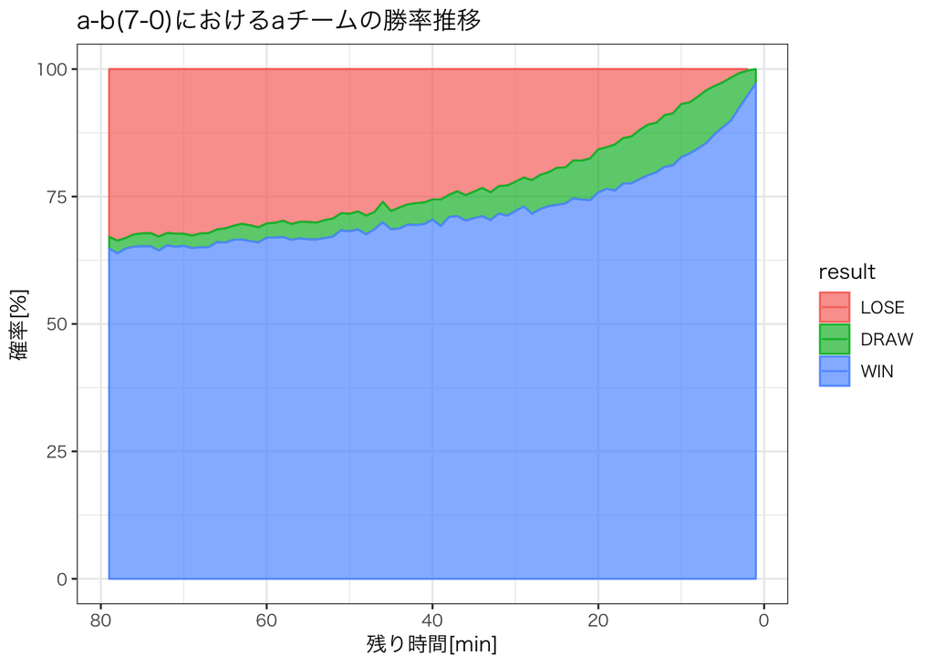

```r
time <- 79 #残り時間
p7 <- 2.4375 / 80 #得点期待値
p5 <- 1.3125 / 80 #得点期待値
p3 <- 1.0357 / 80 #得点期待値
i <- 10000 #試行回数
a <- 7 #現在のAチームの得点
b <- 0 #現在のBチームの得点

res <- matrix(0, nrow=i, ncol=1)

df <- data.frame(matrix(rep(NA, 4), nrow=1))[numeric(0), ]
colnames(df) <- c("DRAW", "LOSE", "WIN", "remaining_time")

for (t in time:1) {

for (n in 1:i) {

  res_a <- runif(t)
  res_b <- runif(t)

  score_a <- a + 7 * sum(res_a < p7) + 5 * sum(res_a >= p7 & res_a < (p7+p5)) + 3 * sum(res_a >= (p7+p5) & res_a < (p7+p5+p3))
  score_b <- b + 7 * sum(res_b < p7) + 5 * sum(res_b >= p7 & res_b < (p7+p5)) + 3 * sum(res_b >= (p7+p5) & res_b < (p7+p5+p3))

  if (score_a == score_b) { #引き分け
   res[n, 1] <- "DRAW"
 } else if (score_a > score_b) { #aの勝ち
   res[n, 1] <- "WIN"
 } else  #aの負け
   res[n, 1] <- "LOSE"

}
  tmp <-
    res %>%
    as.data.frame() %>%
    dplyr::rename(result=V1) %>%
    dplyr::group_by(result) %>%
    dplyr::summarise(rate = n() / i * 100) %>%
    tidyr::spread(key = result, value = rate) %>%
    dplyr::mutate(remaining_time=t)

  df <- dplyr::bind_rows(df, tmp)

  res <- matrix(0, nrow=i, ncol=1)
}

tmp <- paste0("a-b(", a, "-", b, ")におけるaチームの勝率推移")

df %>%
  tidyr::gather(key = result, value = rate, WIN, DRAW, LOSE) %>%
  transform(result = factor(result, levels = c("LOSE", "DRAW", "WIN"))) %>%
  ggplot(aes(x = remaining_time, y = rate, color = result)) +
  geom_line(position="stack") +
  geom_ribbon(aes(ymin = 0, ymax = 1, group = result, fill = result), position = "stack", alpha = 0.7) +
  scale_x_reverse() +
  xlab("残り時間[min]") +
  ylab("確率[%]") +
  ggtitle(tmp)
```

## ラグビー(レベル違うver)

### シミュレーションモデル

ラグビーでも得点期待値が異なる場合を考える

```r
red
```

```
##   順位                         チーム 勝点 勝 分 負  T  G PG DG 反則 得点
## 1    1 神戸製鋼コベルコスティーラーズ   30  6  1  0 50 35 11  0   64  353
## 2    2         サントリーサンゴリアス   26  6  0  1 34 25  5  0   63  239
## 3    3     トヨタ自動車ヴェルブリッツ   26  5  1  1 34 20  9  0   61  237
## 4    4      NTTｺﾐｭﾆｹｰｼｮﾝｽﾞｼｬｲﾆﾝｸﾞｱｰｸｽ   19  3  0  4 37 22  7  0   69  252
## 5    5            NECグリーンロケッツ   14  3  0  4 25 17  4  0   76  171
## 6    6         豊田自動織機シャトルズ   12  3  0  4 20 15 10  1   59  163
## 7    7         日野レッドドルフィンズ    6  1  0  6 15  9 10  0   71  123
## 8    8         宗像サニックスブルース    0  0  0  7 11  4  4  0   85   75
##   失点 得失
## 1  156  197
## 2  164   75
## 3  135  102
## 4  192   60
## 5  191  -20
## 6  233  -70
## 7  261 -138
## 8  281 -206
```

redリーグ首位の神戸製鋼コベルコスティーラーズと最下位の宗像サニックスブルースで考える  
神戸製鋼コベルコスティーラーズは1試合あたり、  
7点: T＋Gは5.000回  
5点: T(Gは失敗)は2.1428回 3点: PG or DGは 1.5714回  
宗像サニックスブルースは1試合あたり、  
7点: T＋Gは0.5714回  
5点: T(Gは失敗)は1.000回 3点: PG or DGは 0.5714回  
の得点期待値である  
サッカーと異なり、被トライ数のデータがなかったので今回はこれをそのまま使う

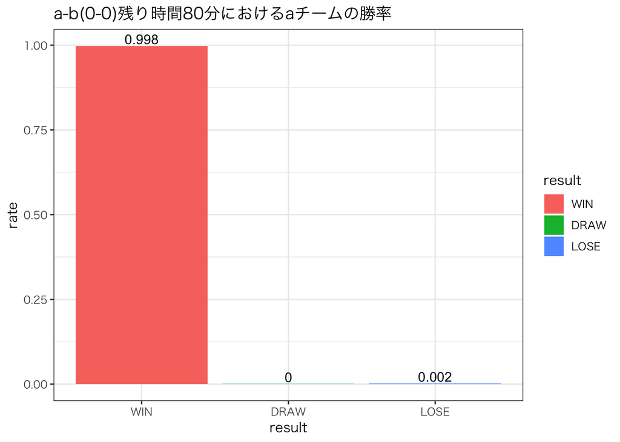

```r
t <- 80 #残り時間
pa7 <- 5 / 80 #aチームの得点期待値
pa5 <- 2.1428 / 80 #aチームの得点期待値
pa3 <- 1.5714 / 80 #aチームの得点期待値
pb7 <- 0.5714 / 80 #bチームの得点期待値
pb5 <- 1 / 80 #bチームの得点期待値
pb3 <- 0.5714 / 80 #bチームの得点期待値
i <- 10000 #試行回数
a <- 0 #現在のAチームの得点
b <- 0 #現在のBチームの得点

res <- matrix(0, nrow=i, ncol=1)

for (n in 1:i) {

  res_a <- runif(t)
  res_b <- runif(t)

  score_a <- a + 7 * sum(res_a < pa7) + 5 * sum(res_a >= p7 & res_a < (pa7+pa5)) + 3 * sum(res_a >= (pa7+pa5) & res_a < (pa7+pa5+pa3))
  score_b <- b + 7 * sum(res_b < pb7) + 5 * sum(res_b >= p7 & res_b < (pb7+pb5)) + 3 * sum(res_b >= (pb7+pb5) & res_b < (pb7+pb5+pb3))

  if (score_a == score_b) { #引き分け
   res[n, 1] <- "DRAW"
 } else if (score_a > score_b) { #aの勝ち
   res[n, 1] <- "WIN"
 } else  #aの負け
   res[n, 1] <- "LOSE"

}

tmp <- paste0("a-b(", a, "-", b, ")残り時間", t, "分におけるaチームの勝率")

res %>%
  as.data.frame() %>%
  dplyr::rename(result=V1) %>%
  dplyr::group_by(result) %>%
  dplyr::summarise(rate = n() / i) %>%
  transform(result = factor(result, levels = c("WIN", "DRAW", "LOSE"))) %>%
  ggplot(aes(x=result, y=rate, fill=result)) +
  geom_col() +
  geom_text(aes(label=round(rate, 3), vjust=-0.2)) +
  ggtitle(tmp)
```

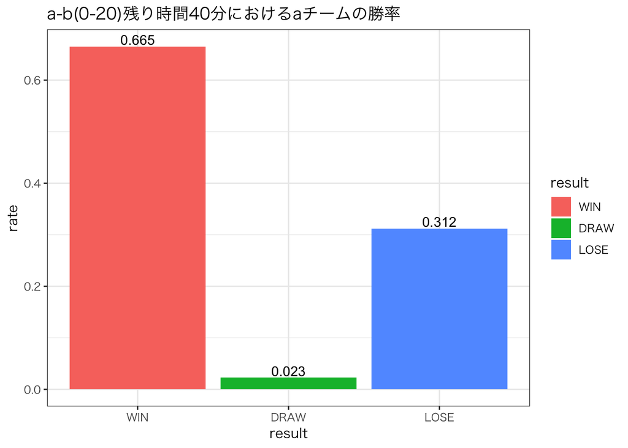

```r
t <- 40 #残り時間
pa7 <- 5 / 80 #aチームの得点期待値
pa5 <- 2.1428 / 80 #aチームの得点期待値
pa3 <- 1.5714 / 80 #aチームの得点期待値
pb7 <- 0.5714 / 80 #bチームの得点期待値
pb5 <- 1 / 80 #bチームの得点期待値
pb3 <- 0.5714 / 80 #bチームの得点期待値
i <- 10000 #試行回数
a <- 0 #現在のAチームの得点
b <- 20 #現在のBチームの得点

res <- matrix(0, nrow=i, ncol=1)

for (n in 1:i) {

  res_a <- runif(t)
  res_b <- runif(t)

  score_a <- a + 7 * sum(res_a < pa7) + 5 * sum(res_a >= p7 & res_a < (pa7+pa5)) + 3 * sum(res_a >= (pa7+pa5) & res_a < (pa7+pa5+pa3))
  score_b <- b + 7 * sum(res_b < pb7) + 5 * sum(res_b >= p7 & res_b < (pb7+pb5)) + 3 * sum(res_b >= (pb7+pb5) & res_b < (pb7+pb5+pb3))

  if (score_a == score_b) { #引き分け
   res[n, 1] <- "DRAW"
 } else if (score_a > score_b) { #aの勝ち
   res[n, 1] <- "WIN"
 } else  #aの負け
   res[n, 1] <- "LOSE"

}

tmp <- paste0("a-b(", a, "-", b, ")残り時間", t, "分におけるaチームの勝率")

res %>%
  as.data.frame() %>%
  dplyr::rename(result=V1) %>%
  dplyr::group_by(result) %>%
  dplyr::summarise(rate = n() / i) %>%
  transform(result = factor(result, levels = c("WIN", "DRAW", "LOSE"))) %>%
  ggplot(aes(x=result, y=rate, fill=result)) +
  geom_col() +
  geom_text(aes(label=round(rate, 3), vjust=-0.2)) +
  ggtitle(tmp)
```

点差が一定の場合、残り時間が減るにつれてどのように勝率が変わるのかを調べてみる

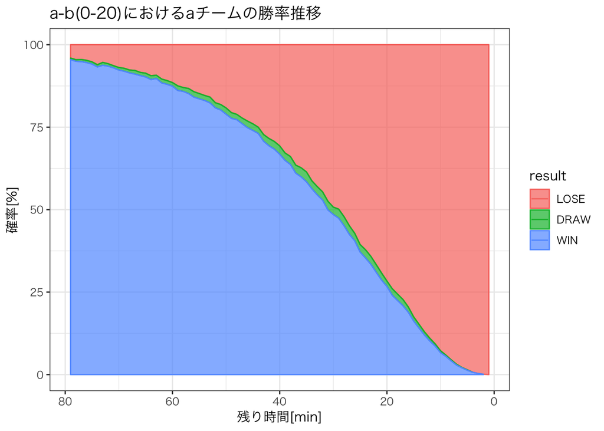

```r
time <- 79 #残り時間
pa7 <- 5 / 80 #aチームの得点期待値
pa5 <- 2.1428 / 80 #aチームの得点期待値
pa3 <- 1.5714 / 80 #aチームの得点期待値
pb7 <- 0.5714 / 80 #bチームの得点期待値
pb5 <- 1 / 80 #bチームの得点期待値
pb3 <- 0.5714 / 80 #bチームの得点期待値
i <- 10000 #試行回数
a <- 0 #現在のAチームの得点
b <- 20 #現在のBチームの得点

res <- matrix(0, nrow=i, ncol=1)

df <- data.frame(matrix(rep(NA, 4), nrow=1))[numeric(0), ]
colnames(df) <- c("DRAW", "LOSE", "WIN", "remaining_time")

for (t in time:1) {

for (n in 1:i) {

  res_a <- runif(t)
  res_b <- runif(t)

  score_a <- a + 7 * sum(res_a < pa7) + 5 * sum(res_a >= p7 & res_a < (pa7+pa5)) + 3 * sum(res_a >= (pa7+pa5) & res_a < (pa7+pa5+pa3))
  score_b <- b + 7 * sum(res_b < pb7) + 5 * sum(res_b >= p7 & res_b < (pb7+pb5)) + 3 * sum(res_b >= (pb7+pb5) & res_b < (pb7+pb5+pb3))

  if (score_a == score_b) { #引き分け
   res[n, 1] <- "DRAW"
 } else if (score_a > score_b) { #aの勝ち
   res[n, 1] <- "WIN"
 } else  #aの負け
   res[n, 1] <- "LOSE"

}
  tmp <-
    res %>%
    as.data.frame() %>%
    dplyr::rename(result=V1) %>%
    dplyr::group_by(result) %>%
    dplyr::summarise(rate = n() / i * 100) %>%
    tidyr::spread(key = result, value = rate) %>%
    dplyr::mutate(remaining_time=t)

  df <- dplyr::bind_rows(df, tmp)

  res <- matrix(0, nrow=i, ncol=1)
}

tmp <- paste0("a-b(", a, "-", b, ")におけるaチームの勝率推移")

df %>%
  tidyr::gather(key = result, value = rate, WIN, DRAW, LOSE) %>%
  transform(result = factor(result, levels = c("LOSE", "DRAW", "WIN"))) %>%
  ggplot(aes(x = remaining_time, y = rate, color = result)) +
  geom_line(position="stack") +
  geom_ribbon(aes(ymin = 0, ymax = 1, group = result, fill = result), position = "stack", alpha = 0.7) +
  scale_x_reverse() +
  xlab("残り時間[min]") +
  ylab("確率[%]") +
  ggtitle(tmp)
```

神戸製鋼と宗像は差がありすぎたので、適当なパラメータでも検証する

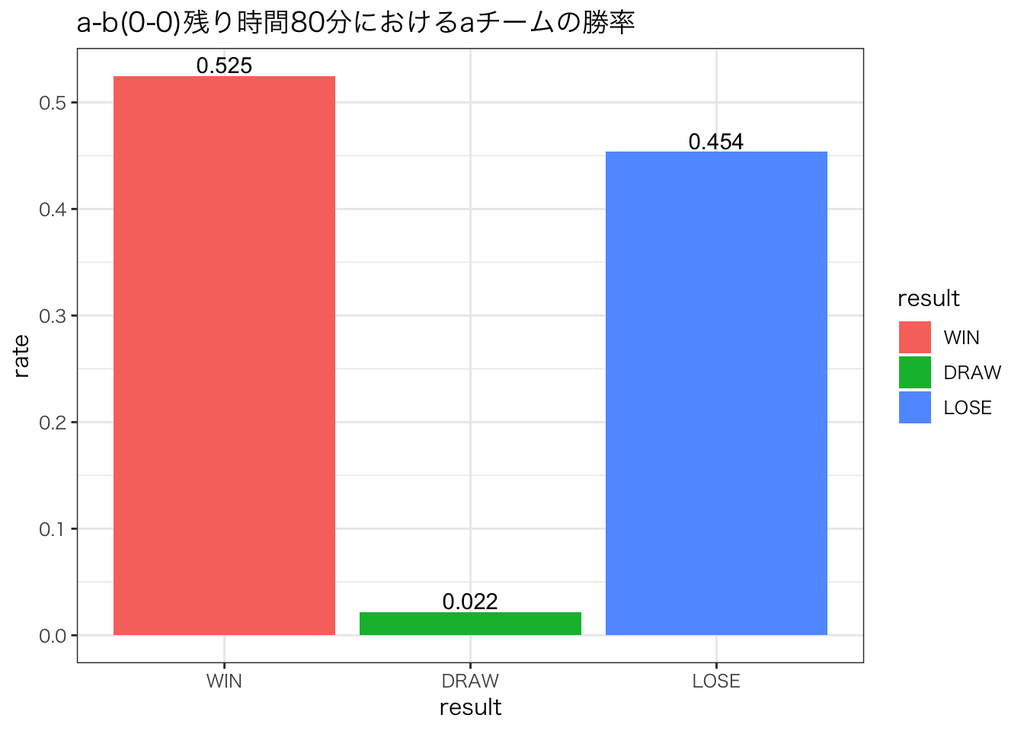

```r
t <- 80 #残り時間
pa7 <- 3 / 80 #aチームの得点期待値
pa5 <- 2 / 80 #aチームの得点期待値
pa3 <- 1 / 80 #aチームの得点期待値
pb7 <- 3 / 80 #bチームの得点期待値
pb5 <- 1 / 80 #bチームの得点期待値
pb3 <- 2 / 80 #bチームの得点期待値
i <- 10000 #試行回数
a <- 0 #現在のAチームの得点
b <- 0 #現在のBチームの得点

res <- matrix(0, nrow=i, ncol=1)

for (n in 1:i) {

  res_a <- runif(t)
  res_b <- runif(t)

  score_a <- a + 7 * sum(res_a < pa7) + 5 * sum(res_a >= p7 & res_a < (pa7+pa5)) + 3 * sum(res_a >= (pa7+pa5) & res_a < (pa7+pa5+pa3))
  score_b <- b + 7 * sum(res_b < pb7) + 5 * sum(res_b >= p7 & res_b < (pb7+pb5)) + 3 * sum(res_b >= (pb7+pb5) & res_b < (pb7+pb5+pb3))

  if (score_a == score_b) { #引き分け
   res[n, 1] <- "DRAW"
 } else if (score_a > score_b) { #aの勝ち
   res[n, 1] <- "WIN"
 } else  #aの負け
   res[n, 1] <- "LOSE"

}

tmp <- paste0("a-b(", a, "-", b, ")残り時間", t, "分におけるaチームの勝率")

res %>%
  as.data.frame() %>%
  dplyr::rename(result=V1) %>%
  dplyr::group_by(result) %>%
  dplyr::summarise(rate = n() / i) %>%
  transform(result = factor(result, levels = c("WIN", "DRAW", "LOSE"))) %>%
  ggplot(aes(x=result, y=rate, fill=result)) +
  geom_col() +
  geom_text(aes(label=round(rate, 3), vjust=-0.2)) +
  ggtitle(tmp)
```

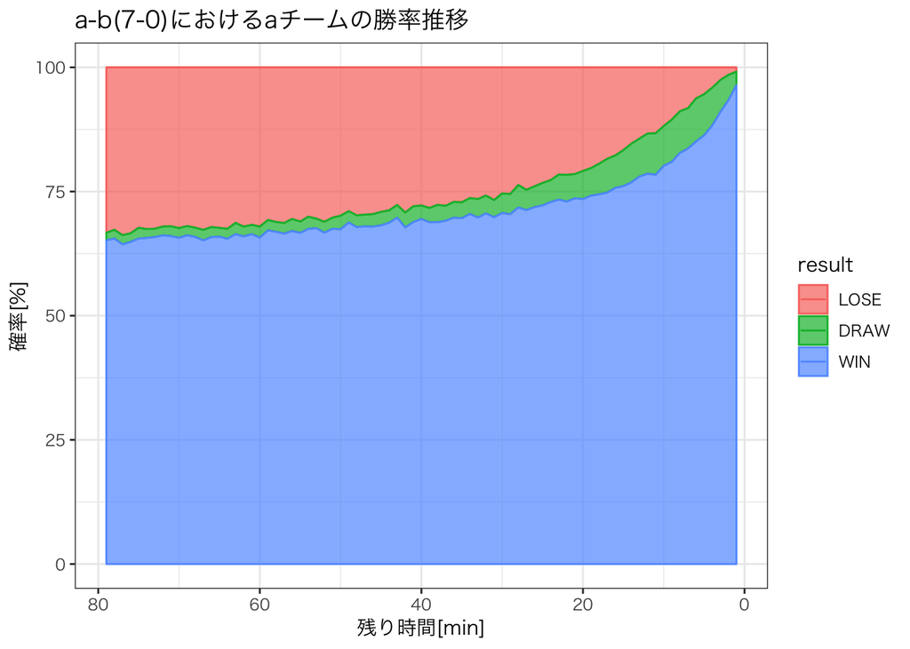

```r
time <- 79 #残り時間
pa7 <- 3 / 80 #aチームの得点期待値
pa5 <- 2 / 80 #aチームの得点期待値
pa3 <- 1 / 80 #aチームの得点期待値
pb7 <- 3 / 80 #bチームの得点期待値
pb5 <- 1 / 80 #bチームの得点期待値
pb3 <- 2 / 80 #bチームの得点期待値
i <- 10000 #試行回数
a <- 7 #現在のAチームの得点
b <- 0 #現在のBチームの得点

res <- matrix(0, nrow=i, ncol=1)

df <- data.frame(matrix(rep(NA, 4), nrow=1))[numeric(0), ]
colnames(df) <- c("DRAW", "LOSE", "WIN", "remaining_time")

for (t in time:1) {

for (n in 1:i) {

  res_a <- runif(t)
  res_b <- runif(t)

  score_a <- a + 7 * sum(res_a < pa7) + 5 * sum(res_a >= p7 & res_a < (pa7+pa5)) + 3 * sum(res_a >= (pa7+pa5) & res_a < (pa7+pa5+pa3))
  score_b <- b + 7 * sum(res_b < pb7) + 5 * sum(res_b >= p7 & res_b < (pb7+pb5)) + 3 * sum(res_b >= (pb7+pb5) & res_b < (pb7+pb5+pb3))

  if (score_a == score_b) { #引き分け
   res[n, 1] <- "DRAW"
 } else if (score_a > score_b) { #aの勝ち
   res[n, 1] <- "WIN"
 } else  #aの負け
   res[n, 1] <- "LOSE"

}
  tmp <-
    res %>%
    as.data.frame() %>%
    dplyr::rename(result=V1) %>%
    dplyr::group_by(result) %>%
    dplyr::summarise(rate = n() / i * 100) %>%
    tidyr::spread(key = result, value = rate) %>%
    dplyr::mutate(remaining_time=t)

  df <- dplyr::bind_rows(df, tmp)

  res <- matrix(0, nrow=i, ncol=1)
}

tmp <- paste0("a-b(", a, "-", b, ")におけるaチームの勝率推移")

df %>%
  tidyr::gather(key = result, value = rate, WIN, DRAW, LOSE) %>%
  transform(result = factor(result, levels = c("LOSE", "DRAW", "WIN"))) %>%
  ggplot(aes(x = remaining_time, y = rate, color = result)) +
  geom_line(position="stack") +
  geom_ribbon(aes(ymin = 0, ymax = 1, group = result, fill = result), position = "stack", alpha = 0.7) +
  scale_x_reverse() +
  xlab("残り時間[min]") +
  ylab("確率[%]") +
  ggtitle(tmp)
```